# Intervalos de confianza

Clase 1: Introducción

Luis Fernando Apáez Álvarez

20/12/2021

- Planteamiento
- Método pivotal

Introducidos por **Jerzi Neyman** en 1937, los intervalos de confianza buscan “encerrar” el valor de un parámetro desconocido, con cierto nivel de certeza. Estos intervalos tienen extremos aleatorios y son calculados con base en la información tomada de la muestra; de tal manera, con ellos se consigue un intervalo de valores donde puede estar el valor verdadero de un parámetro (asegurado con cierta confienza), así, en esta sección, ya no buscaremos un valor determinado para la estimación de un parámetro, más bien será la búsqueda de intervalos donde pueda encontrarse dicho valor. La confianza o certeza a la que hacen alusión los intervalos buscados debe ser alta y con un margen de error pequeño, siendo así que la probabilidad de que el valor verdadero del parámetro se encuentre en dicho intervalo es muy alta.

## Planteamiento

Consideremos una muestra aleatoria $X_{1},\ldots,X_{n}$ de alguna distribución cuya función de densidad es $f(x,\theta)$, con $\theta\in \Theta$ desconocido. Se busca ahora reducir el espacio parametral para disminuir el *desconocimiento* de $\theta$ en $f(x,\theta)$. Para ello tomamos $\Theta_{1}\subseteq \Theta$ tal que puede afirmarse que $\theta\in\Theta_{1}$ con cierta certeza y con cierto margen de error. Formalizamos lo anterior en la siguiente definición

**Definición:** Sean $X_{1},\ldots,X_{n}$ una muestra aleatoria de alguna distribución con función de densidad $f(x;\theta)$, $\theta\in\Theta$ desconocido, y $\alpha\in(0,1)$. Definimos un intervalo de confianza para $\theta$ como el intervalo aleatorio de la forma $\left(\hat{\theta}_{1}, \hat{\theta}_{2}\right)$, donde $\hat{\theta}_{1}$ y $\hat{\theta}_{2}$ son estadísticas que satisfacen que

$$\mathbb{P}\left(\hat{\theta}_{1}<\theta<\hat{\theta}_{2}\right)=1-\alpha \hspace{3cm} (\ast)$$

*Observaciones:*

- A las estadísticas $\hat{\theta}_{1}$ y $\hat{\theta}_{2}$ se les conoce como límite inferior y superior, respectivamente, del intervalo de confianza.
- Al número $1-\alpha$ se le conoce como *coeficiente de confianza* o *nivel de confianza*. Así, buscamos que el coeficiente de confianza sea cercano a uno para tener una probabilidad alta de que $\left(\hat{\theta}_{1},\hat{\theta}_{2}\right)$ contenga a $\theta$, de modo que buscamos equivalentemente que $\alpha$ sea cercano a cero.
- Considerando que los extremos aleatorios del intervalo aleatorio son estadísticas del parámetro $\theta$, tenemos que éstos están en función de la muestra $X_{1},\ldots,X_{n}$, donde $X_{i}$ es una variable aleatoria para $i=1,\ldots,n$. De tal manera, de acuerdo a los distintos valores que tome la muestra tendremos distintos **intervalos** correspondientes a los intervalos aleatorios, donde el valor verdadero del parámetro estará en estos **intervalos** con cierto nivel de confianza. El comportamiento anterior puede ilustrarse gráficamente como

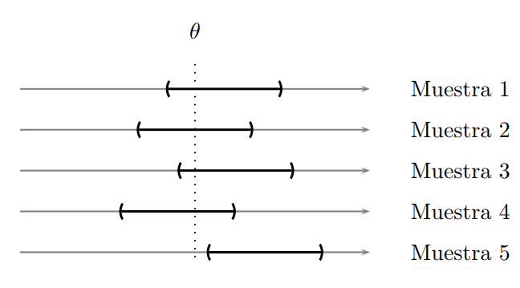

*Imagen extraída de [1]*

- Dado que se está trabajando con el enfoque clásico, decir “la probabilidad de que $\theta$ pertenezca al intervalo $\left(\hat{\theta}_{1}, \hat{\theta}_{2}\right)$ es de $1-\alpha$” es incorrecto pues se está suponiendo que $\theta$ es un valor fijo pero desconocido y no una variable aleatoria. En cambio, es correcto decir que “la probabilidad de que el intervalo_ $\left(\hat{\theta}_{1},\hat{\theta}_{2}\right)$ contenga el valor de $\theta$ es de $1-\alpha$”.
- Utilizando el enfoque frecuentista de la probabilidad, se puede afirmar que un gran número de intervalos (o realizaciones) correspondientes del intervalo aleatorio contendrán el valor del parámetro $\theta$ el $(1-\alpha)\cdot 100 \%$ de las veces.

**Ejemplo:** Sea $X_{1},\ldots, X_{n}$ una muestra aleatoria de la distribución $\mathcal{N}(\mu,\sigma^{2})$, con $\mu$ desconocido. Sabemos que la estadística $T(X)=\overline{X}\sim \mathcal{N}(\mu, \sigma^{2}/n)$ y $Z\sim \mathcal{N}(0,1)$. Notemos que

```r
# phi(1.96)
pnorm(1.96, mean=0, sd=1)
```

```
## [1] 0.9750021
```

Luego

$$\begin{align*}
&-1.96<Z<1.96 \ \ \textrm{syss} \ \ -1.96<\frac{\overline{X}-\mu}{\sigma/\sqrt{n}}<1.96 \ \ \textrm{syss} \ \ \overline{X}-1.96\cdot \frac{\sigma}{\sqrt{n}}<\mu<\overline{X}+1.96\cdot \frac{\sigma}{\sqrt{n}}\\
\Rightarrow \ \ & \mathbb{P}\left(\overline{X}-1.96\cdot \frac{\sigma}{\sqrt{n}}<\mu<\overline{X}+1.96\cdot \frac{\sigma}{\sqrt{n}}\right)=0.95
\end{align*}$$

que indica que hay una probabilidad de $0.95$ de obtener una muestra tal que el intervalo

$$\left(\overline{X}-1.96\cdot \frac{\sigma}{\sqrt{n}},\overline{X}+1.96\cdot \frac{\sigma}{\sqrt{n}}\right) \hspace{3cm} (1)$$

se incluya al valor de $\mu$. Así, en este caso se ha tomado el valor de $\alpha$ de $0.05$ que pertmite alcanzar la probabilidad de $0.95$ ($1-\alpha=0.95$). Si la muestra aleatoria toma los valores $x_{1},\ldots,x_{n}$ entonces la estadística $\overline{x}$ tomará también un valor dado, de modo que una realización del intervalo aleatorio en $(1)$ es

$$\left(\overline{x}-1.96\cdot \frac{\sigma}{\sqrt{n}},\overline{x}+1.96\cdot \frac{\sigma}{\sqrt{n}}\right)\hspace{3.2cm} (2)$$

Así, puede decirse que los intervalos (o realizaciones) correspondientes al intervalo aleatorio en $(1)$ contendrán el valor de $\mu$ un 95$\%$ de las veces. También, se dice que el intervalo numérico (o realización del intervalo aleatorio) en $(2)$ es un intervalo de confianza para $\mu$ con un nivel del $95\%$.

## Método pivotal

La manera de hallar las estadísticas $\hat{\theta_{1}}$ y $\hat{\theta_{2}}$ que cumplan con la ecuación $(\ast)$ no es un problema fácil de resolver. En muchos de los casos lo que se encuentra son aproximaciones para dichas estadísticas, de modo que lo que se obtiene son intervalos de confianza aproximados.

El método que se abordará se conoce como *método pivotal*, el cual presenta restricciones al exigirse una variable aleatoria con ciertas características. Para ello, suponemos que podemos encontrar una función de la muestra aleatoria y del parámetro desconocido, digamos $q(X_{1},\ldots,X_{n};\theta)$, con distribución de probabilidad completamente conocida que no depende de $\theta$. De tal manera que puedan determinarse dos números $a<b$ tales que

$$\mathbb{P}\left(a<q(X_{1},\ldots, X_{n};\theta)<b\right)=1-\alpha$$

de donde se busca desprender el parámetro $\theta$ de la expresión anterior conforme a la ecuación $(\ast)$. A la función $q$ se le conoce como cantidad pivotal pues de ella se busca obtener el término $\theta$. Formalmente

**Definición:** Sean $X_{1},\ldots,X_{n}$ una muestra aleatoria de alguna distribución con función de densidad $f(x;\theta)$ y $q(X_{1},\ldots,X_{n}:\theta)$ una función que depende de la muestra aleatoria y del parámetro desconocido. Si la distribución de $q$ no depende de $\theta$, entonces denominamos a dicha función como **cantidad pivotal**.

**Ejemplos:** Consideremos una muestra aleatoria de la distribución $\mathcal{N}(\mu,1)$, donde $\mu$ es fijo pero desconocido. Sabemos que $\overline{X}\sim \mathcal{N}(\mu, 1/n)$. Luego observamos las siguientes funciones

- La función $q_{1}=\frac{\overline{X}-\mu}{1/\sqrt{n}}\sim \mathcal{N}(0,1)$ es una cantidad pivotal para $\mu$.
- La función $q_{2}=\overline{X}-\mu\sim \mathcal{N}(0,1/n)$ es también una cantidad pivotal para $\mu$.
- La función $q_{3}=\frac{\overline{X}}{\mu}\sim \mathcal{N}(1,1/n\mu^{2})$ no es una cantidad pivotal para $\mu$ puesto que la distribución asociada a $q_{3}$ depende del propio parámetro.

En la siguiente clase se abordará el método **pivotal para intervalos de confianza**.